# Tankstatistik

Bart R. Dutkiewicz

25.03.2025

## Tank- und Verbrauchsstatistik eines Toyota Corolla Bj. 1998 ab Juni 2014

In diesem Dokument wird die Tankstatistik eines Toyota Corolla Bj. 1998 seit 2014 fortlaufend ausgewertet. Das Auto wird durch den Urheber dieser Auswertung überwiegend innerhalb der Region Stuttgart bewegt und an städischen (sehr selten: an der Autobahn) Tankstellen der selben Region betankt.

Dieses Dokument und der zugrundeliegende Code ist **Work-In-Progress** (seit 2015) und das Datum bezieht sich auf die letzte *wesentliche* Änderung im Code. **Der Datensatz wird laufend ergänzt.** Die verwendete Version von R ist 4.4.3.

**Bei dem Auto handelt es sich um:**

- Hersteller: Toyota
- Modell: Corolla
- Erstzulassung: 10.06.1998
- Treibstoff: Benzin (E95)
- Tankvolumen: 40 Liter
- Leergewicht: 920kg
- Hubraum: 1587cm3
- Leistung: 81kw
- Max. Umdrehungen: 6000U/min
- Höchstgeschw.: 195km/h

**Folgende Daten werden anhand der Tankquittungen und Notizen/Photos auf einem Mobiltelefon (Kilometerstände) erfasst:**

- Datum
- Uhrzeit
- Getankte Liter (E95)
- Literpreis
- Betrag in Euro
- Gefahrene Kilometer bis zur nächsten Betankung
- Kilometerstand
- Anmerkungen zu Rabatten an der Kasse, Ungenauigkeiten etc. (nicht abgebildet)

**Die folgende Analyse teilt sich in folgende Abschnitte (Tabs) auf:**

- Datenaufbereitung: die Rohdaten werden eingelesen und zur weiteren Verarbeitung vorbereitet. Lücken im Datensatz werden durch Schätzung auf Grundlage benachbarter Werte und durch Rückrechnung aufgefüllt. Zudem werden einige Quotienten berechnet.
- Gesamtzeitraum: es werden kumulierte Summen, arithmetrische Mittel und Mediane (wo aussagekräftig) über den gesamten Zeitraum berechnet und letzere beide miteinander verglichen.
- Jährliche Auswertung: selbiges für die Einzeljahre.
- Abbildungen: für einige Variablen werden die zeitlichen Verläufe mit allen Beobachtungen abgebildet. Zudem werden die Jahressummen und -mittelwerte abgebildet. Bei letzeren werden die beiden Mittel für jedes Jahr gegenübergestellt.
- Data Story.
- Alle Quelltexte, Dateien und Lizenz

**Hinweise:**

- Die Datenaufbereitung und -auswertung erfolgt ausschließlich mithilfe der R-Basispakete. Dies war eine Entscheidung aus autodidaktischen Gründen und wird so beibehalten. Für Abbildungen wird tidyverse verwendet.
- Die Ergebnisse werden in den Übersichten nicht interpretiert. Hierzu ist wurde die Data Story erstellt.
- In diesem Markdown-Dokument ist das Skript nur Teilweise einsehbar. Vollständige Quelltexte aller Varianten sind im Tab “Alle Quelltexte und Lizenz” verlinkt.

### Datenaufbereitung

#### Der Rohdatensatz

```
##     Tag Monat Jahr Stunde Minute Liter Euro_Liter  Euro      km km_gesamt
## 1    NA    NA 2014     NA     NA 40.00         NA 60.00 440.200        NA
## 2    15     7 2014     NA     NA 38.59      1.569 60.55 503.200        NA
## 3    22     8 2014     NA     NA 37.23      1.559 58.04 478.500        NA
## 4    12    10 2014     NA     NA 38.38      1.489 57.15 358.700        NA
## 5     7    11 2014     NA     NA 33.29      1.439 47.90 450.900        NA
## 6     8    12 2014     NA     NA 40.12      1.389 55.73 451.500        NA
## 7    22     1 2015     NA     NA 38.00      1.290 49.02 454.500        NA
## 8     6     3 2015     NA     NA 40.24      1.419 57.10 513.100        NA
## 9     8     3 2015     16     28 38.90      1.419 55.20 293.200        NA
## 10   11     3 2015     16     46 37.09      1.449 37.09 329.000        NA
## 11   18     4 2015     NA     NA 25.42      1.439 36.58 463.400        NA
## 12   25     4 2015     13     42 37.23      1.419 52.83 493.400        NA
## 13   17     5 2015     NA     NA 10.00      1.439 14.29 125.000        NA
## 14   26     5 2015     NA     NA 37.47      1.449 54.30 470.800        NA
```

[output cut: 91 more lines]

Es ist zu sehen, dass der Datensatz aufgrund von verlorenen oder nicht-erhobenen Daten lückenhaft ist

#### Rekonstruktion, Teil 1

Im folgenden werden Tag und Monat durch Annahme rekonstruiert und der Literpreis berechnet:

```r
# Rekonstruktion von [1, 1]; [1, 2] (Tag und Monat)
df.raw[1, 1] <- 20; df.raw[1, 2] <- 6

# Rekonstruktion von [1, 7] (Literpreis)
df.raw[1, 7] <- df.raw[1, 8]/df.raw[1, 6]
```

#### Aufbereitung, Teil 1

Im Folgenden werden Tag, Monat, Jahr zu einer Datumsvariable zusammengefasst und die Tagedifferenz zwischen zwei Betankungen berechnet.

```r
# Erzeugen einer Datumsvariable und Einfügen dieser
# in die Tabelle.
Datum <- paste(df.raw$Jahr,"-",df.raw$Monat,"-",df.raw$Tag, sep="")
df.raw$Datum <- as.Date(Datum)

# Berechnen der vergangenen Tage zwischen zwei Betankungen
Tage <- as.integer(diff(df.raw$Datum))
df.raw$Tage <- c(Tage, NA)
```

#### Datenrekonstruktion, Teil 2

```r
## Rekonstruktion von [58, 9] bis [66, 9] (Kilometer je Tankfüllung in 2018)
# Durchschnittliche Kilometer am Tag 2019
df.raw.2019 <- subset(df.raw, Jahr == "2019")
df.raw.2019 <- df.raw.2019[, c(9, 12)]
Mittel.a.2019 <- lapply(df.raw.2019, function(x) mean(x))
Mittel.a.2019$km.Tag <- (Mittel.a.2019$km/Mittel.a.2019$Tage)

# Rückrechnung
df.raw[58, 9] <- df.raw[58, 12] * Mittel.a.2019$km.Tag
df.raw[59, 9] <- df.raw[59, 12] * Mittel.a.2019$km.Tag
df.raw[60, 9] <- df.raw[60, 12] * Mittel.a.2019$km.Tag
df.raw[61, 9] <- df.raw[61, 12] * Mittel.a.2019$km.Tag
df.raw[62, 9] <- df.raw[62, 12] * Mittel.a.2019$km.Tag
df.raw[63, 9] <- df.raw[63, 12] * Mittel.a.2019$km.Tag
df.raw[64, 9] <- df.raw[64, 12] * Mittel.a.2019$km.Tag
df.raw[65, 9] <- df.raw[65, 12] * Mittel.a.2019$km.Tag
df.raw[66, 9] <- df.raw[66, 12] * Mittel.a.2019$km.Tag
```

#### Datenrekonstruktion, Teil 3

Der Gesamtkilimeterstand wurde bis einschließlich 2019 nicht erhoben und wird im Folgenden anhand der gefahrenen Kilometer je Tankfüllung rückberechnet

```r
# Rekonstruktion von [1, 10] bis [75, 10] (Gesamtkilometerstand)
for (i in 76:2){
  df.raw[i-1, 10] <- df.raw[i, 10] - df.raw[i, 9]
}
```

#### Aufbereitung, Teil 2

Die Rekonstruktion ist an dieser Stelle abgeschlossen. Im Folgenden werden einige Hilfsobjekte aus dem Speicher entfernt, zwei Datenformate geändert und Quotienten gebildet.

```r
## Bereinigung Arbeitsumgebung
# Entfernen aller ab hier unnötigen Objekte
rm(df.raw.2019, Mittel.a.2019, Datum, i, Tage)


## Bilden einiger Quotienten
# Liter je km
df.raw$Liter.km <- df.raw$Liter / df.raw$km

# Euro je km
df.raw$Euro.km <- df.raw$Euro / df.raw$km

# Kilometer je Tag
df.raw$km.Tag <- df.raw$km / df.raw$Tage

# Liter je Tag
df.raw$Liter.Tag <- df.raw$Liter / df.raw$Tage

# Euro je Tag
df.raw$Euro.Tag <- df.raw$Euro / df.raw$Tage


## Format
# Tag und Monat als Ganzzahlen speichern
df.raw$Tag <- as.integer(df.raw$Tag)
df.raw$Monat <- as.integer(df.raw$Monat)

# Runden aller Spalten auf jeweils sinnvolle Dezimalstellen
df.raw$km <- round(df.raw$km)
df.raw$km_gesamt <- round(df.raw$km_gesamt)
df.raw$Liter.km <- round(df.raw$Liter.km, 4)
df.raw$Euro.km <- round(df.raw$Euro.km, 4)
df.raw$km.Tag <- round(df.raw$km.Tag, 3)
df.raw$Liter.Tag <- round(df.raw$Liter.Tag, 4)
df.raw$Euro.Tag <- round(df.raw$Euro.Tag, 4)
```

#### Aufbereitung, Teil 3

Im Folgenden werden alle Spalten gerundet.

Für die weitere Auswertung ist dies nicht zwingend nötig, aber das Einlesen des exportierten, aufbereiteten Datensatzes in eine SQL-Datenbank wird durch eine uneinheitliche Anzahl von Nachkommastellen sehr erschwert (erzwingt unexaktes und speicherineffizentes Zahlenformat).

Um dem zu begegnen, werden alle Spalten gerundet. Einige Distanz- und Kostenspalten behalten dabei “ungewohnt” viele Nachkommastellen, weil gröber gerundete Werte zu oft gleich zueinander sind.

```r
# Runden aller Spalten für einheitliche Anzahl an Nachkommastellen
df.raw$km <- round(df.raw$km)
df.raw$km_gesamt <- round(df.raw$km_gesamt)
df.raw$Liter.km <- round(df.raw$Liter.km, 4)
df.raw$Euro.km <- round(df.raw$Euro.km, 4)
df.raw$km.Tag <- round(df.raw$km.Tag, 3)
df.raw$Liter.Tag <- round(df.raw$Liter.Tag, 4)
df.raw$Euro.Tag <- round(df.raw$Euro.Tag, 4)
```

#### Rekonstruierter Datensatz

```
##     Tag Monat Jahr Stunde Minute Liter Euro_Liter  Euro  km km_gesamt
## 1    20     6 2014     NA     NA 40.00      1.500 60.00 440    108823
## 2    15     7 2014     NA     NA 38.59      1.569 60.55 503    109326
## 3    22     8 2014     NA     NA 37.23      1.559 58.04 478    109804
## 4    12    10 2014     NA     NA 38.38      1.489 57.15 359    110163
## 5     7    11 2014     NA     NA 33.29      1.439 47.90 451    110614
## 6     8    12 2014     NA     NA 40.12      1.389 55.73 452    111066
## 7    22     1 2015     NA     NA 38.00      1.290 49.02 454    111520
## 8     6     3 2015     NA     NA 40.24      1.419 57.10 513    112033
## 9     8     3 2015     16     28 38.90      1.419 55.20 293    112326
## 10   11     3 2015     16     46 37.09      1.449 37.09 329    112655
## 11   18     4 2015     NA     NA 25.42      1.439 36.58 463    113119
## 12   25     4 2015     13     42 37.23      1.419 52.83 493    113612
## 13   17     5 2015     NA     NA 10.00      1.439 14.29 125    113737
## 14   26     5 2015     NA     NA 37.47      1.449 54.30 471    114208
```

[output cut: 197 more lines]

#### Datenstruktur des rekonstruierten Datensatzes

```r
str(df.raw)
```

```
## 'data.frame':    105 obs. of  17 variables:
##  $ Tag       : int  20 15 22 12 7 8 22 6 8 11 ...
##  $ Monat     : int  6 7 8 10 11 12 1 3 3 3 ...
##  $ Jahr      : int  2014 2014 2014 2014 2014 2014 2015 2015 2015 2015 ...
##  $ Stunde    : int  NA NA NA NA NA NA NA NA 16 16 ...
##  $ Minute    : int  NA NA NA NA NA NA NA NA 28 46 ...
##  $ Liter     : num  40 38.6 37.2 38.4 33.3 ...
##  $ Euro_Liter: num  1.5 1.57 1.56 1.49 1.44 ...
##  $ Euro      : num  60 60.5 58 57.1 47.9 ...
##  $ km        : num  440 503 478 359 451 452 454 513 293 329 ...
##  $ km_gesamt : num  108823 109326 109804 110163 110614 ...
##  $ Datum     : Date, format: "2014-06-20" "2014-07-15" ...
##  $ Tage      : int  25 38 51 26 31 45 43 2 3 38 ...
##  $ Liter.km  : num  0.0909 0.0767 0.0778 0.107 0.0738 ...
##  $ Euro.km   : num  0.136 0.12 0.121 0.159 0.106 ...
##  $ km.Tag    : num  17.61 13.24 9.38 13.8 14.54 ...
##  $ Liter.Tag : num  1.6 1.02 0.73 1.48 1.07 ...
##  $ Euro.Tag  : num  2.4 1.59 1.14 2.2 1.55 ...
```

#### Datensatzvarianten erzeugen

Trennung des Datensatzes in eine Exportvariante und eine Auswertungsvariante. Die unvollständige jüngste Beobachtung wird für die weitere Auswertung nicht berücksichtigt und aus dem Auswertungsdatensatz entfernt.

```r
# Aufbereiteter Datensatz inkl. unv. jüngster Beobachtung für den Export
df.export <- df.raw

# Aufbereiteter Datensatz exkl. unv. jüngster Beobachtung für die weitere Auswertung
df.raw <- df.raw[-nrow(df.raw), ]
df <- df.raw
rm(df.raw)
```

#### Berechnung der Summen und Mittel über den Gesamtzeitraum und die Einzeljahre

Der Code zur Auswertung wird hier aufgrund großer Länge und Repetitivität ausgelassen und ist im grundliegenden Skript auf GitHub und Posit.Cloud zu Verfügung gestellt.

### Gesamtzeitraum

#### Summen der seit Beginn der Erhebung am 20.06.2014:

Gesamtsummen seit Juni 2014

| Liter | Euro | km | Tage | Betankungen |
| --- | --- | --- | --- | --- |
| 3582 | 5205 | 42954 | 3860 | 104 |

#### Mittel über den gesamten Zeitraum je Betankung

In den linken Spalten sind arithmetrisches Mittel und Median von:

- Getanke Liter
- Preis in Euro je Liter
- Gezahlte Summe in Euro
- Zurückgelegte Kilometer bis zur nächten Betankung
- Verstrichene Tage bis zur nächsten Betankung
- Verbrauchte Liter je Kilometer
- Kosten in Euro je Kilometer
- Zurückgelegte Kilometer je Tag
- Verbrauchte Liter je Tag
- Kosten in Euro je Tag
- Betankungen je Jahr

In den zwei rechten Spalten sind:

- Absolute Differenzen zwischen Median (Minuend) und arithmetrischem Mittel (Subtrahend)
- Relative Differenzen von selbigem

Gesamtmittel

|  | Arith. Mittel | Median | Absolute Differenz | Prozentuale Differenz |
| --- | --- | --- | --- | --- |
| Liter | 34.44 | 37.72 | 3.28 | 8.69 |
| Euro_Liter | 1.45 | 1.42 | -0.03 | -2.19 |
| Euro | 50.04 | 50.84 | 0.80 | 1.58 |
| km | 413.02 | 448.50 | 35.48 | 7.91 |
| Tage | 37.12 | 31.00 | -6.12 | -19.73 |
| Liter.km | 0.08 | 0.08 | 0.00 | 0.84 |
| Euro.km | 0.12 | 0.11 | -0.01 | -6.88 |
| km.Tag | 11.13 | 14.47 | 3.34 | 23.08 |
| Liter.Tag | 0.93 | 1.22 | 0.29 | 23.73 |
| Euro.Tag | 1.35 | 1.64 | 0.29 | 17.79 |

### Jährliche Auswertung

#### Jahressummen*:

Jahressummen

|  | Liter | Euro | km | Betankungen |
| --- | --- | --- | --- | --- |
| 2014 | 228 | 339 | 2683 | 6 |
| 2015 | 574 | 774 | 6756 | 17 |
| 2016 | 620 | 800 | 7929 | 18 |
| 2017 | 368 | 484 | 4326 | 11 |
| 2018 | 395 | 562 | 4361 | 15 |
| 2019 | 283 | 402 | 3190 | 8 |
| 2020 | 297 | 387 | 3374 | 8 |
| 2021 | 188 | 304 | 2464 | 5 |
| 2022 | 157 | 292 | 1994 | 4 |
| 2023 | 235 | 433 | 2904 | 6 |
| 2024 | 238 | 427 | 2973 | 6 |

*Im Jahr 2014 ist nur die zweite Jahreshälfte erhoben

#### Jahresmittel

- Getanke Liter
- Preis in Euro je Liter
- Gezahlte Summe in Euro
- Zurückgelegte Kilometer bis zur nächten Betankung
- Verstrichene Tage bis zur nächsten Betankung
- Verbrauchte Liter je Kilometer
- Kosten in Euro je Kilometer
- Zurückgelegte Kilometer je Tag
- Verbrauchte Liter je Tag
- Kosten in Euro je Tag

#### Arithmetrische Mittel

Jahresmittel (arithmetrisch)

|  | Liter | Euro/Liter | Euro | km | Tage | Liter/km | Euro/km | km/Tag | Liter/Tag | Euro/Tag |
| --- | --- | --- | --- | --- | --- | --- | --- | --- | --- | --- |
| 2014 | 37.94 | 1.49 | 56.56 | 447.17 | 36.00 | 0.08 | 0.13 | 1.57 | 1.05 | 1.57 |
| 2015 | 33.76 | 1.38 | 45.54 | 397.41 | 21.24 | 0.08 | 0.11 | 2.14 | 1.59 | 2.14 |
| 2016 | 34.42 | 1.30 | 44.42 | 440.50 | 20.83 | 0.08 | 0.10 | 2.13 | 1.65 | 2.13 |
| 2017 | 33.45 | 1.32 | 44.04 | 393.27 | 31.73 | 0.09 | 0.11 | 1.39 | 1.05 | 1.39 |
| 2018 | 26.34 | 1.42 | 37.48 | 290.73 | 25.73 | 0.09 | 0.13 | 1.46 | 1.02 | 1.46 |
| 2019 | 35.40 | 1.42 | 50.20 | 398.75 | 41.88 | 0.09 | 0.13 | 1.20 | 0.85 | 1.20 |
| 2020 | 37.09 | 1.31 | 48.34 | 421.75 | 57.12 | 0.09 | 0.11 | 0.85 | 0.65 | 0.85 |
| 2021 | 37.61 | 1.62 | 60.87 | 492.80 | 64.20 | 0.08 | 0.12 | 0.95 | 0.59 | 0.95 |
| 2022 | 39.25 | 1.87 | 73.08 | 498.50 | 89.50 | 0.08 | 0.15 | 0.82 | 0.44 | 0.82 |
| 2023 | 39.09 | 1.84 | 72.10 | 484.00 | 64.33 | 0.08 | 0.15 | 1.12 | 0.61 | 1.12 |
| 2024 | 39.66 | 1.79 | 71.20 | 495.50 | 52.67 | 0.08 | 0.14 | 1.35 | 0.75 | 1.35 |

#### Mediane

Jahresmittel (median)

|  | Liter | Euro/Liter | Euro | km | Tage | Liter/km | Euro/km | km/Tag | Liter/Tag | Euro/Tag |
| --- | --- | --- | --- | --- | --- | --- | --- | --- | --- | --- |
| 2014 | 38.48 | 1.49 | 57.59 | 451.5 | 34.5 | 0.09 | 0.13 | 1.67 | 1.12 | 1.67 |
| 2015 | 37.47 | 1.42 | 50.51 | 451.0 | 24.0 | 0.08 | 0.11 | 2.10 | 1.56 | 2.10 |
| 2016 | 37.47 | 1.29 | 48.54 | 449.0 | 19.0 | 0.08 | 0.11 | 2.55 | 1.97 | 2.55 |
| 2017 | 38.53 | 1.32 | 50.44 | 436.0 | 31.0 | 0.09 | 0.12 | 1.63 | 1.24 | 1.63 |
| 2018 | 26.54 | 1.46 | 38.72 | 219.0 | 19.0 | 0.12 | 0.18 | 2.04 | 1.40 | 2.04 |
| 2019 | 36.91 | 1.42 | 51.55 | 396.0 | 38.0 | 0.09 | 0.13 | 1.36 | 0.97 | 1.36 |
| 2020 | 37.17 | 1.31 | 47.93 | 452.5 | 56.5 | 0.08 | 0.11 | 0.85 | 0.66 | 0.85 |
| 2021 | 38.50 | 1.61 | 63.01 | 491.0 | 57.0 | 0.08 | 0.13 | 1.11 | 0.68 | 1.11 |
| 2022 | 39.25 | 1.85 | 72.68 | 503.5 | 83.5 | 0.08 | 0.14 | 0.87 | 0.47 | 0.87 |
| 2023 | 38.84 | 1.86 | 72.44 | 483.5 | 66.0 | 0.08 | 0.15 | 1.10 | 0.59 | 1.10 |
| 2024 | 39.52 | 1.77 | 70.98 | 484.5 | 35.5 | 0.08 | 0.15 | 2.00 | 1.11 | 2.00 |

#### Absolute Differenz zwischen Median (Minuend) und arithmetrischem Mittel (Subtrahend) in den Einzeljahren

Absolute Differenz Median - Arith. Mittel

|  | Liter | Euro/Liter | Euro | km | Tage | Liter/km | Euro/km | km/Tag | Liter/Tag | Euro/Tag |
| --- | --- | --- | --- | --- | --- | --- | --- | --- | --- | --- |
| 2014 | 0.55 | 0.00 | 1.03 | 4.33 | -1.50 | 0.00 | 0.00 | 0.10 | 0.06 | 0.10 |
| 2015 | 3.71 | 0.04 | 4.97 | 53.59 | 2.76 | 0.00 | 0.00 | -0.04 | -0.03 | -0.04 |
| 2016 | 3.05 | -0.01 | 4.12 | 8.50 | -1.83 | 0.01 | 0.01 | 0.42 | 0.32 | 0.42 |
| 2017 | 5.08 | 0.00 | 6.40 | 42.73 | -0.73 | 0.00 | 0.00 | 0.24 | 0.19 | 0.24 |
| 2018 | 0.20 | 0.04 | 1.24 | -71.73 | -6.73 | 0.03 | 0.05 | 0.58 | 0.37 | 0.58 |
| 2019 | 1.51 | 0.00 | 1.34 | -2.75 | -3.88 | 0.00 | 0.00 | 0.16 | 0.13 | 0.16 |
| 2020 | 0.08 | 0.01 | -0.41 | 30.75 | -0.62 | -0.01 | -0.01 | 0.00 | 0.01 | 0.00 |
| 2021 | 0.89 | -0.01 | 2.14 | -1.80 | -7.20 | 0.00 | 0.00 | 0.16 | 0.09 | 0.16 |
| 2022 | 0.00 | -0.01 | -0.39 | 5.00 | -6.00 | 0.00 | 0.00 | 0.05 | 0.03 | 0.05 |
| 2023 | -0.25 | 0.01 | 0.33 | -0.50 | 1.67 | 0.00 | 0.00 | -0.02 | -0.02 | -0.02 |
| 2024 | -0.15 | -0.02 | -0.22 | -11.00 | -17.17 | 0.00 | 0.00 | 0.65 | 0.36 | 0.65 |

#### Prozentuale Differenz zwischen Median (Minuend) und arithmetrischem Mittel (Subtrahend) in den Einzeljahren

Relative Differenz Median - Arith. Mittel in Prozent

|  | Liter | Euro/Liter | Euro | km | Tage | Liter/km | Euro/km | km/Tag | Liter/Tag | Euro/Tag |
| --- | --- | --- | --- | --- | --- | --- | --- | --- | --- | --- |
| 2014 | 1.43 | 0.25 | 1.79 | 0.96 | -4.35 | 0.47 | 0.84 | 5.89 | 5.54 | 5.89 |
| 2015 | 9.90 | 2.76 | 9.84 | 11.88 | 11.52 | -2.25 | -2.32 | -1.90 | -1.83 | -1.90 |
| 2016 | 8.15 | -0.52 | 8.49 | 1.89 | -9.65 | 6.37 | 6.72 | 16.54 | 16.23 | 16.54 |
| 2017 | 13.19 | -0.21 | 12.69 | 9.80 | -2.35 | 3.76 | 3.21 | 14.69 | 15.18 | 14.69 |
| 2018 | 0.76 | 2.51 | 3.20 | -32.75 | -35.44 | 25.25 | 27.09 | 28.53 | 26.73 | 28.53 |
| 2019 | 4.08 | -0.26 | 2.61 | -0.69 | -10.20 | 4.75 | 3.28 | 11.62 | 12.96 | 11.62 |
| 2020 | 0.22 | 0.57 | -0.85 | 6.80 | -1.11 | -7.05 | -8.20 | 0.25 | 1.31 | 0.25 |
| 2021 | 2.30 | -0.50 | 3.40 | -0.37 | -12.63 | 2.66 | 3.75 | 14.23 | 13.26 | 14.23 |
| 2022 | -0.01 | -0.67 | -0.54 | 0.99 | -7.19 | -1.02 | -1.55 | 6.20 | 6.69 | 6.20 |
| 2023 | -0.66 | 0.81 | 0.46 | -0.10 | 2.53 | -0.55 | 0.56 | -2.12 | -3.26 | -2.12 |
| 2024 | -0.37 | -1.13 | -0.31 | -2.27 | -48.36 | 1.86 | 1.91 | 32.38 | 32.34 | 32.38 |

### Abbildungen

#### Vorarbeit

(Pakete werden an dieser Stelle geladen)

```r
# Pakete laden
library(tidyverse)
library(wesanderson) #Farbpaletten
```

```r
## Vorarbeit
# Jahre (bisher als Zeilennamen) in reguläre Variable packen (damit ggplot2 zurecht kommt)
Summen.Jahr$Jahr <- as.integer(rownames(Summen.Jahr))
# Alles auf ganze Zahlen Runden (sonst hässliche Darstellung)
Summen.Jahr <- round(Summen.Jahr, digits = 0)
# Data Frame als Tibble
df <- as_tibble(df)

# Jahresmittelwerte in brauchbare Form bringen und zusammenführen
long.Mittel.Jahr.a <- Mittel.Jahr.a
names(long.Mittel.Jahr.a) <- str_sub(names(long.Mittel.Jahr.a), 1, nchar(names(long.Mittel.Jahr.a))-2) #Letzte beide Zeichen in den Spaltennamen Entfernen
long.Mittel.Jahr.a$Jahr <- as.integer(rownames(long.Mittel.Jahr.a)) #Jahr in Spalte ziehen
long.Mittel.Jahr.a$Mittel <- rep("arithmetrisch", nrow(long.Mittel.Jahr.a)) #Mittel in Spalte hinzufügen

long.Mittel.Jahr.m <- Mittel.Jahr.m
names(long.Mittel.Jahr.m) <- str_sub(names(long.Mittel.Jahr.m), 1, nchar(names(long.Mittel.Jahr.m))-2) #Das Gleiche für den Median
long.Mittel.Jahr.m$Jahr <- as.integer(rownames(long.Mittel.Jahr.m))
long.Mittel.Jahr.m$Mittel <- rep("median", nrow(long.Mittel.Jahr.m))

Mittel.Jahr <- rbind(long.Mittel.Jahr.a, long.Mittel.Jahr.m) #Zusammenführen
rownames(Mittel.Jahr) <- NULL #Zeilennamen löschen
Mittel.Jahr <- as_tibble(Mittel.Jahr) #In Tibble umwandeln


## Bereinigung Arbeitsumgebung
# Entfernen aller ab hier unnötigen Objekte
rm(long.Mittel.Jahr.a, long.Mittel.Jahr.m)
```

#### Jahressummen

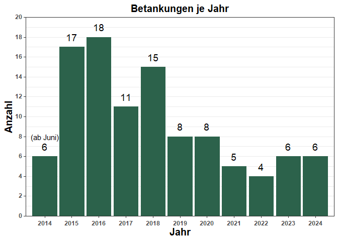

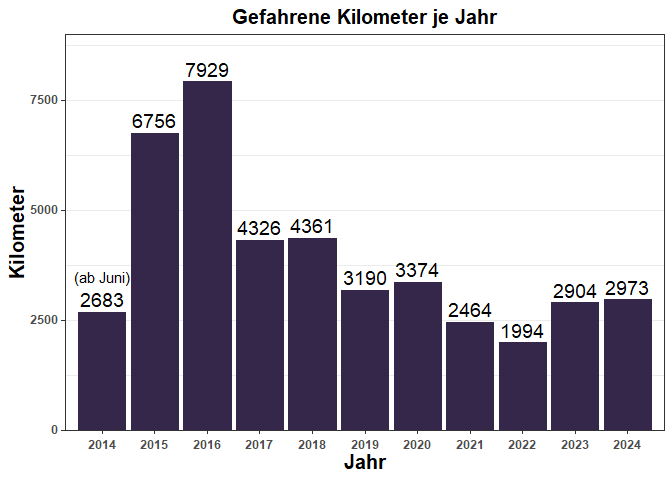

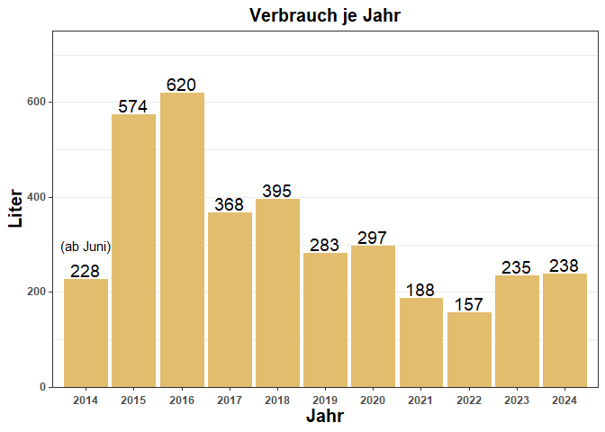

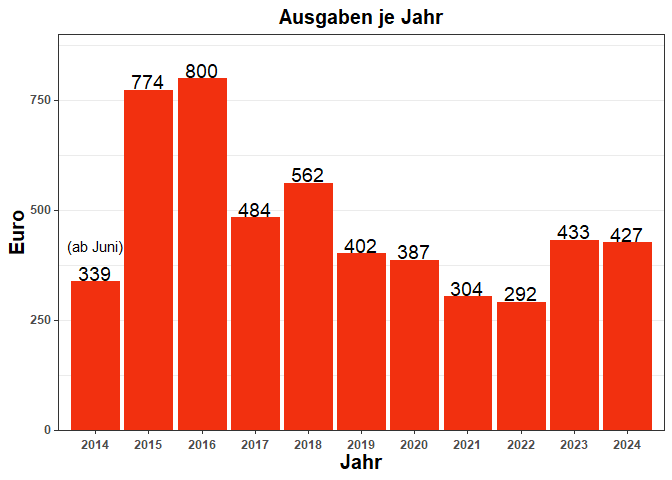

#### Verläufe

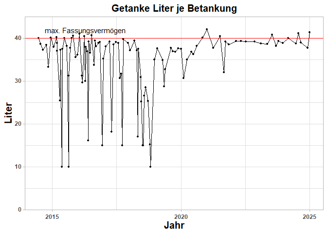

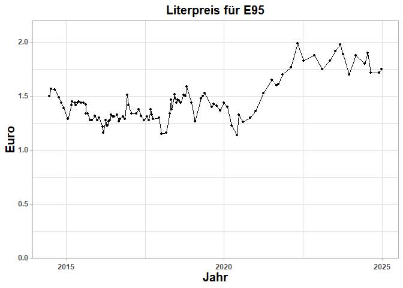

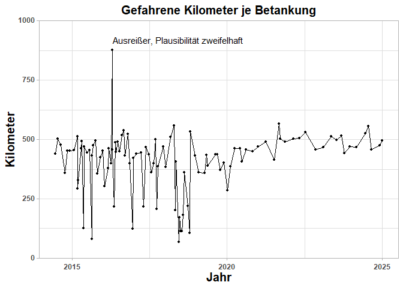

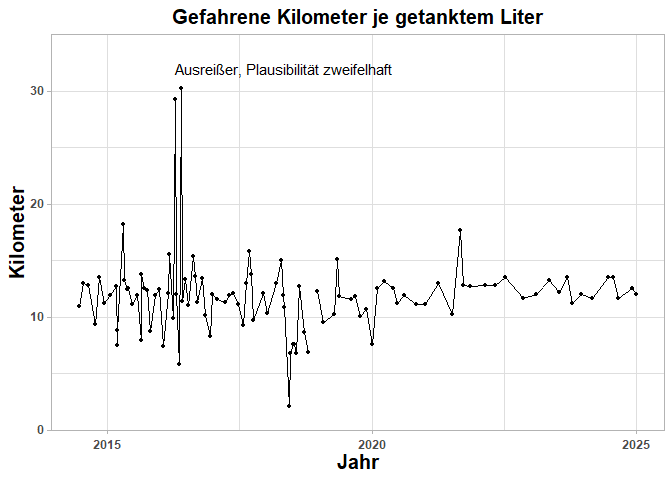

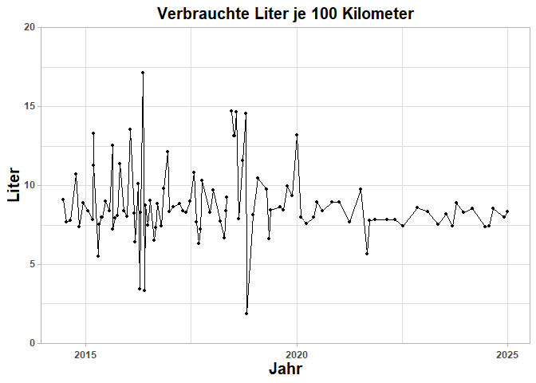

#### TBD: Kilometer je Tag und zeitlicher Abstand zur nächsten Betankung

#### TBD: Reichweite je Tank + Farbskala Abstand je Betankung

#### Jahresmittel (artithmetrisch und median)

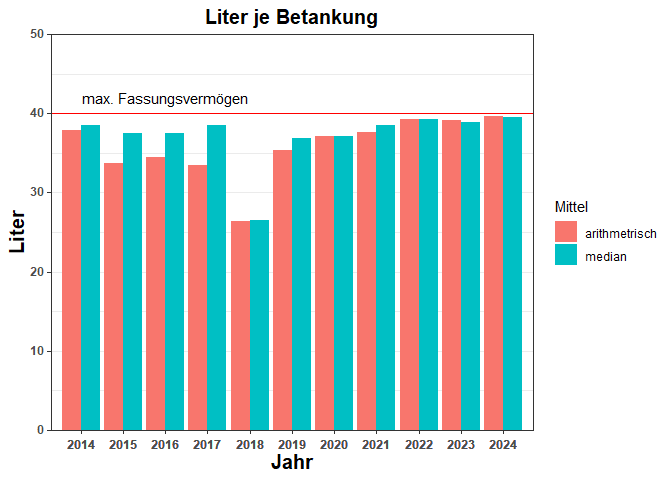

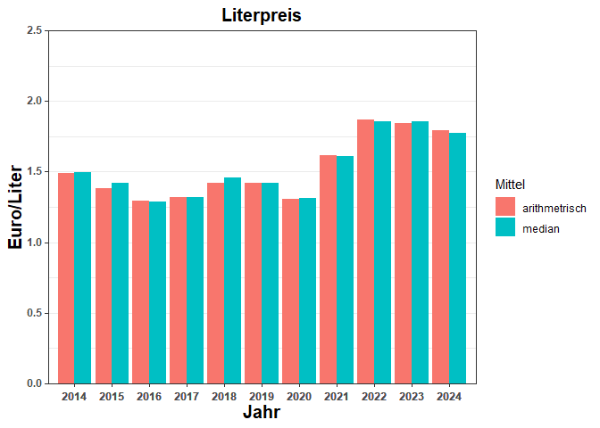

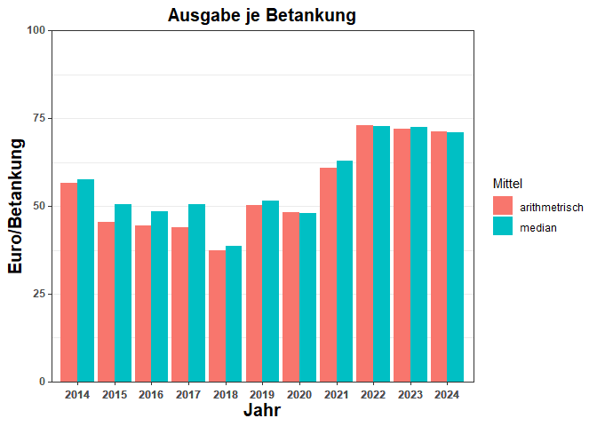

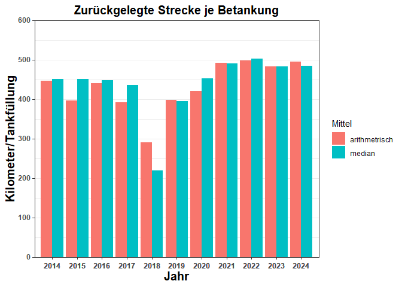

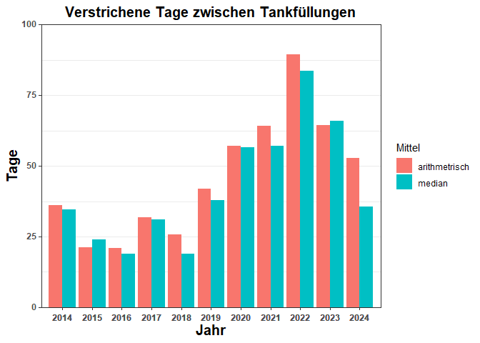

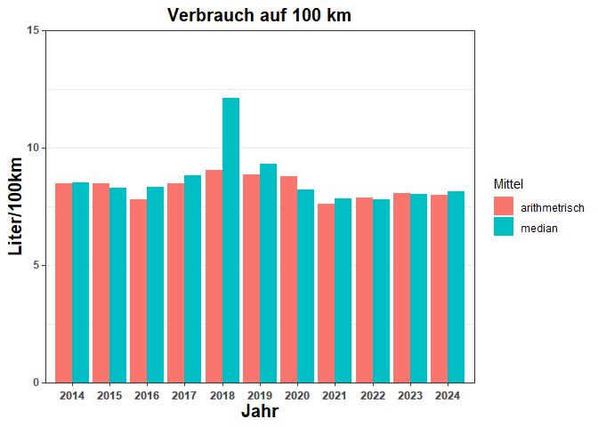

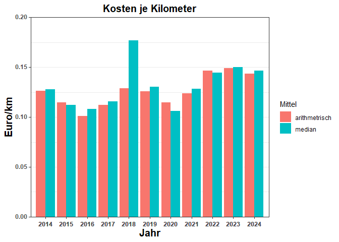

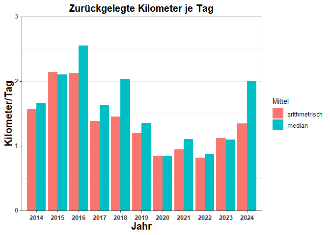

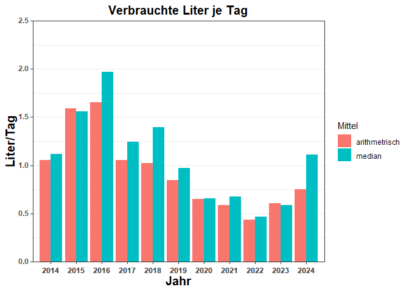

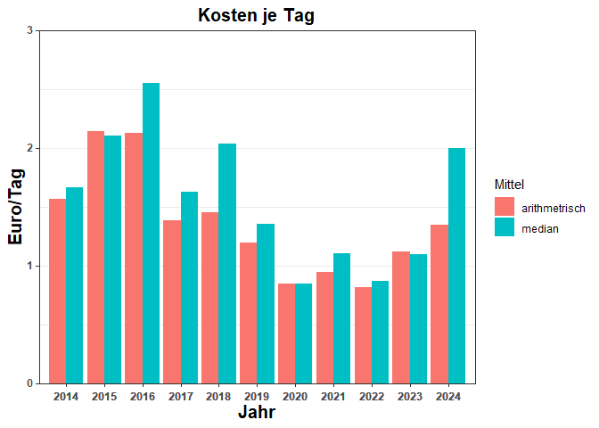

### Data Story

#### Einleitung

In den vorangegangenen Tabs wurden die beschreibenden Statistiken und Abbildungen weitestgehend ohne Kommentar und Interpretation präsentiert. Im Folgenden wird eine kleine Tour durch die interessantesten Einglicke dieses Datensatzes gegeben.

Zunächst wird ein Blick auf die akkumulierten Werte geworfen.

Gesamtsummen seit Juni 2014

| Liter | Euro | km | Tage | Betankungen |
| --- | --- | --- | --- | --- |
| 3582 | 5205 | 42954 | 3860 | 104 |

Die Summen von zurückgelegten Kilometern und den damit Zusammenhängenden Kosten lassen im Bezug auf die verstrichene Zeit auf eine nur sporadische Nutzung des Autos annehmen. Aber lassen sich im Verlauf der Erhebung Änderungen in der Fahrzeugnutzung feststellen?

#### Relativer Benzinverbrauch

Auf Einkaufsfahren wurden bis 2020 Strecken von weniger als 5 km, bisweilen weniger als 1 km. Diese sind bei Verbrennermotoren aus technischen Gründen am verbrauchsstärksten. Aufgrund des Lebenswandels finden solche Fahren kaum noch statt. Schlägt sich dies aber auch in der Statistik nieder? Hierzu werden die je Tankfüllung (die Höchstkapazität beträgt 40 Liter) zurückgelegten, Kilometer und dessen geläufigerer Kehrwert (außerdem um zwei Stellen verschoben), der Literverbrauch auf 100 Kilometer näher betrachtet:

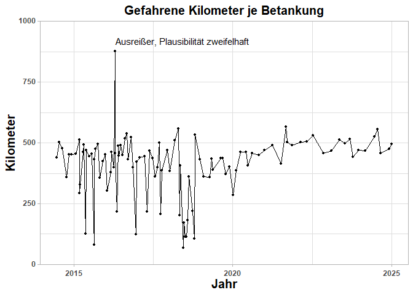

Zunächst fällt ein enormer Ausreißer im Jahr 2016 auf, welcher bei 877,2 km zwischen zwei liegt, wesentlich über dem zweithöchsten je gemessenen Wert von 566km zwischen zwei Betankungen und dem Median über die gesamte Erhebungszeit von unter 500 km liegt. Dieser Wert ist gänzlich unplausibel und am ehesten ein Tippfehler (wohlmöglich müsste es stattdessen 577,2 km heißen. Dies wäre jedoch auch dann noch der Spitenwert). Für die folgenden beschreibenden Statistiken wird der Wert weder nachträglich abgeändert noch herausgenommen. Für mögliche spätere schließende Statistiken muss er jedoch berücksichtigt werden, da unplausible Ausreißer diese verfälschen.

“Zwischen zwei Betankungen” ist dabei weitgehend synonym mit “Zurückgelegte Kilometer auf eine volle Betankung”, wie folgende Abbildung zeigt:

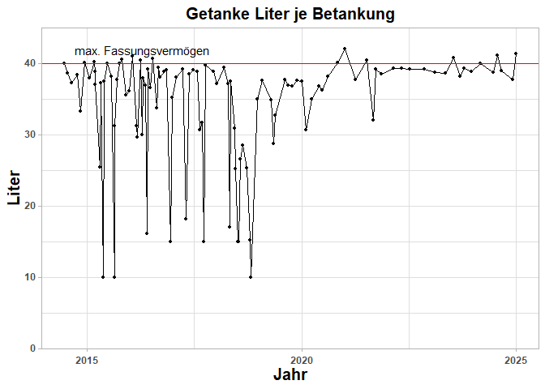

Der Tank wurde meist weitgehend leer gefahren und wieder vollgetankt.

Das geläufigere Maß “Liter auf 100 km” stellt sich wie folgt dar:

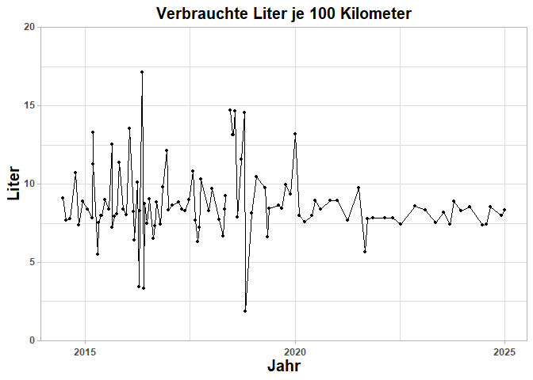

Optisch ist anhand der Abbildung, welche alle erhobenen Werte enthält (die Ursache für die fehlende Linie konnte bislang nicht herausgefunden werden), nicht festzustellen, dass sich um das Jahr 2020 etwas im relativen Verbrauch geändert hätte. Darum wird im Folgenden ein Blick auf den Verlauf der Jahresmittelwerte (arithmetrisches Mittel und Median) geworfen.

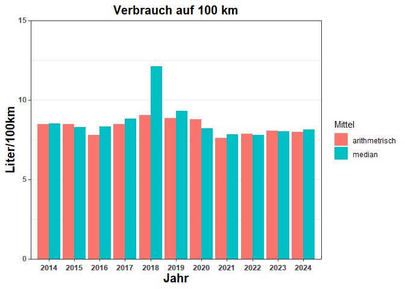

Von 2019 bis 2021 sind beide Mittel zurückgegangen, was die These von einem geringeren relativen Verbrauch durch geändertes Fahrverhalten ab 2020 untermauert.

#### Absoluter Verbrauch

Auch die gesamte Nutzung des Autos - unabhängig von den Streckenlängen - ist erheblich zurückgegangen, wie ein Blick auf die zurückgelegten Kilometer je Tag zwischen zwei Betankungen und die verstrichenen Tage dazwischen verraten:

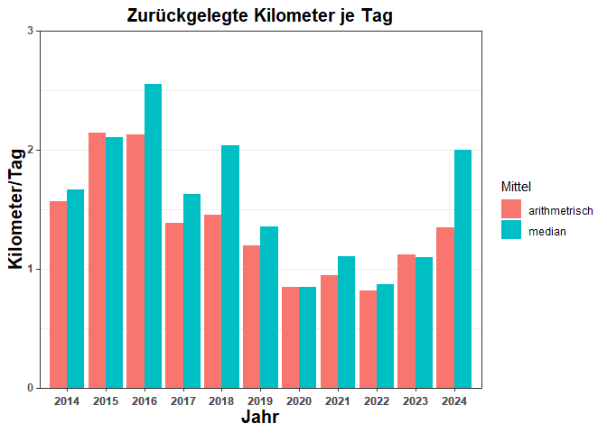

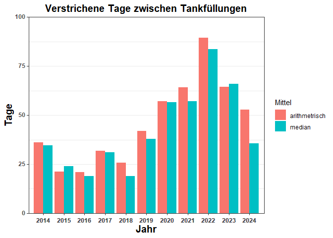

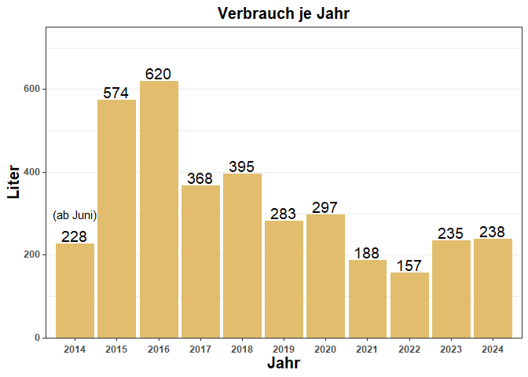

### Export

Im grundlegenden R-Skript werden folgende Exporte ausgeführt:

- Der Rekonstruierte Datensatz
- Gesamtsummen und -mittel
- Jahressummen und -mittel
- **TBD:** SQLite (öffentlich)
- **TBD:** postgreSQL (persönlich)

Diese Exporte und der dazugehörige Code sind kein Teil dieses Dokuments und stehen auf GitHub und Posit.Cloud zur Verfügung.

### Alle Quelltexte, Dateien und Lizenz

#### GitHub

Das vollständige Projekt mitsamt aller Quelltexte und Daten (Input/Output) ist unter https://github.com/bartdutkiewicz/Tankstatistik zur Verfügung gestellt.

#### Posit.Cloud

Das grundlegende R-Skript und das R-Markdown-Dokument sind auf Posit.Cloud unter https://posit.cloud/content/3318758 zur Verfügung gestellt (Benutzerkonto erforderlich).

#### RPubs

Dieses R-Markdown-Dokument ist auf RPubs unter https://rpubs.com/Dutkiewicz/Tankstatistik zur Verfügung gestellt.

#### Lizenz

Das gesamte Projekt und insbesondere der Datensatz ist mit der [Creative Commons Attribution 4.0 International Public License](https://creativecommons.org/licenses/by/4.0/legalcode.txt) lizenziert.